# GeoPick: Centroid and uncertainty calculation

October 17, 2023

This Notebook illustrates how **GeoPick** v1.0.3 applies the point-radius method [1] to calculate the centroid (Darwin Core’s decimalLatitude and decimalLongitude) and uncertainty (Darwin Core’s coordinateUncertaintyInMeters) associated with a georeferenced locality description (Darwin Core’s verbatimLocality) by approximating the smallest enclosing circle of a geometry. The example given below is for a polygon with a corrected center [2, 3]. For line, polyline and multipolygon geometries the calculation is analogous. GeoPick follows steps 1 to 6 to deliver the final results. The case in which the centroid falls on top of the geometry when calculating its smallest enclosing circle would be a simplified version of the process here described, i.e. step 5 below would not be needed.

```r
library(jsonlite)
library(sf)
library(geojsonsf)
library(lwgeom)
library(terra)
library(mapview)
library(ggplot2)
library(gridExtra)
library(leaflet)
library(dplyr)
source("functions.R")
site.colour <- "#e2565b"
vertex.colour <- "black"
candidate1.colour <- "yellow"
candidate2.colour <- "purple"
nearest.colour <- "darkgreen"
centroid1.colour <- "darkgreen"
centroid2.colour <- "blue"
```

## 1 - Specimen’s locality interpretation

The polygon below represents the geometry resulting from retrospective georeferencing, the process by which the textual description of a locality where a specimen was collected is interpreted over a map. This locality description (Darwin Core’s verbatimLocality) was available on a specimen’s associated metadata, i.e. tag, field notebook, etc. The geometry can be directly digitized with **GeoPick**, imported as [Well-Known Text (WKT)](https://en.wikipedia.org/wiki/Well-known_text_representation_of_geometry), or captured from a search to the OpenStreetMap data [Nominatim service](https://nominatim.openstreetmap.org/ui/search.html). The example below corresponds to a locality description of the collection site of a plant in the Cap de Creus area, in northeastern Catalonia, Spain.

```r
source("wkt_example.R")
site.sf <- st_as_sf(st_as_sfc(site.wkt, crs = 4326))
site.sf <- st_as_sf(st_combine(site.sf))
leaflet() %>%
  addTiles() %>%
  addPolygons(data=site.sf, col = site.colour)
```

[interactive chart not shown]

```r
centroid <- st_centroid(site.sf)
xc <- st_coordinates(centroid)[1]
yc <- st_coordinates(centroid)[2]
crs <- paste0("+proj=aeqd +lat_0=", yc, " +lon_0=", xc,
              " +x_0=0 +y_0=0 +R=6371000 +units=m +no_defs +type=crs")
site.tr <- site.sf %>% st_transform(crs)
```

For the given example, the parameterized projection is *“+proj=aeqd +lat_0=42.25042729657 +lon_0=3.23921344496318 +x_0=0 +y_0=0 +R=6371000 +units=m +no_defs +type=crs”*. Below we can see the Earth projected with our site at its center (red cross).

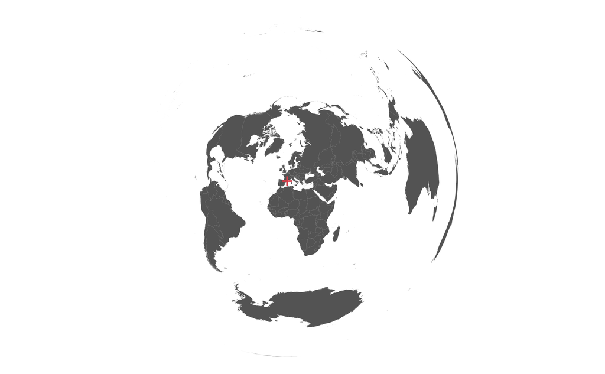

```r
f <- "../data/CNTR_RG_01M_2020_4326.geojson"
world.4326 <- geojson_sf(f)["ISO3_CODE"]
world.tr <- world.4326 %>% st_transform(crs)
p.world <- ggplot() +
  geom_sf(data=world.tr, fill="grey40", linewidth=0) +
  geom_point(aes(x=xc, y=yc), col=site.colour, shape='+', size=9) +
  theme_void()
p.world
```

## 3 - Eventual geometry simplification

If the number of vertices in the geometry is too large, **GeoPick** simplifies it for performance reasons. Currently, **GeoPick** sets the maximum number of vertices to 10 000. For geometries above this threshold, a maximum tolerance of 500m between vertices is applied.

```r
max_points_polygon <- 10000
tolerance <- 500
if(npts(site.tr) > as.integer(max_points_polygon)){
  site.tr <- st_simplify(site.tr, preserveTopology = TRUE, dTolerance = tolerance)
  cat("In our example, the geometry HAS BEEN SIMPLIFIED since it had", npts(site.tr), "vertices\n")
} else {
    cat("In our example, the geometry HAS NOT BEEN SIMPLIFIED since it had", npts(site.tr), "vertices\n")
}
```

In our example, the geometry HAS NOT BEEN SIMPLIFIED since it had 252 vertices

## 4 - Calculate SEC and centroid

With the site projected in [AEQD](https://proj.org/en/9.3/operations/projections/aeqd.html), **GeoPick** calculates the smallest enclosing circle with its corresponding centroid and radius of uncertainty. **GeoPick** uses the *st_minimum_bounding_circle* function of the R package *lwgeom* [4], which in turn uses the *liblwgeom* light-weight geometry library of [PostGIS](https://postgis.net), to approximate the smallest enclosing circle.

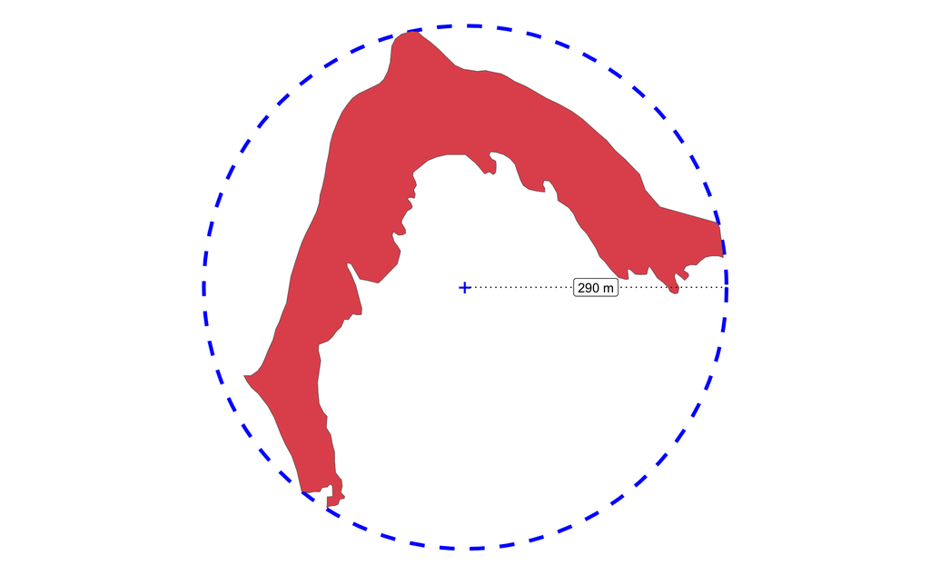

```r
mbc.tr <- st_minimum_bounding_circle(site.tr, nQuadSegs = 30)
mbc.tr.centroid <- st_centroid(mbc.tr)
xc <- st_coordinates(mbc.tr.centroid)[1]
yc <- st_coordinates(mbc.tr.centroid)[2]
radius.line <- st_as_sfc(paste0("LINESTRING (", xc, " ", yc, ", ",
                                st_bbox(mbc.tr)["xmax"], " ", yc, ")")) %>%
  st_set_crs(crs)
uncertainty1 <- paste(round(st_length(radius.line)), "m")
p <- ggplot() +
  geom_sf(data=mbc.tr, fill=NA, col = centroid2.colour, linewidth = 1.5, linetype = "dashed") +
  geom_sf(data=site.tr, fill=site.colour) +
  geom_sf(data=mbc.tr.centroid, shape = '+', col = centroid2.colour, size = 7, linewidth = 2) +
  geom_sf(data=radius.line, linewidth = 0.5, linetype = "dotted") +
  geom_label(aes(x = xc + (st_bbox(mbc.tr)["xmax"] - xc)/2, y = yc),
             label = uncertainty1) +
  theme_void() +
  theme(legend.position = "None")
p
```

## 5 - Correct center if necessary

When the centroid falls outside the geometry, as is the case in our example above, **GeoPick** calculates the corrected center instead [2, 3]. If the centroid had fallen on top of the geometry, **GeoPick** would skip this step and go directly to step 6.

To correct the center, **GeoPick** follows the substeps 5.1 to 5.3:

### 5.1 - Candidates to become the new corrected center

When calculating the corrected center, **GeoPick** gathers a list of candidate points by selecting the vertices of the geometry (5.1.1 black dots). For performance reasons, **GeoPick** restricts this list of candidate points to a sample of 50 (5.1.1 yellow dots) in the case the number of vertices was greater than that. Then, it finds the nearest point on the geometry’s perimeter (5.1.2 green dot) to the centroid that fell outside (5.1.2 blue cross), which may not correspond to an existing geometry vertex, and adds it to the final candidate list (5.1.3 yellow dots).

#### 5.1.1 - Sample of geometry vertices (black dots) as candidate points (yellow dots).

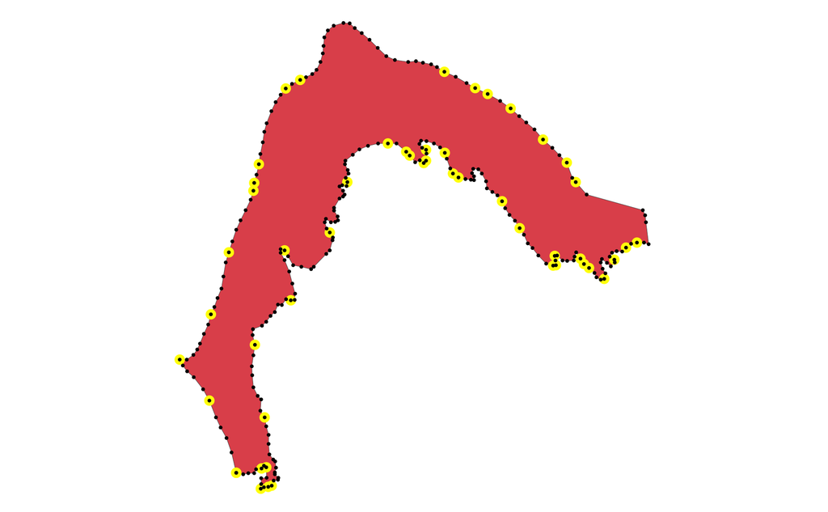

```r
# Check if center correction is needed
need.cc <- ifelse(is.na(as.integer(st_intersects(site.tr, mbc.tr.centroid))), T, F)
if(need.cc){
  # Gather a sample of 50 points from the location's geometry
  n.sample <- 50
  site.pts <- st_cast(site.tr, "POINT") %>% mutate(idx = row.names(.))
  if(nrow(site.pts) > n.sample){
    point.idxs <- sample(1:nrow(site.pts), n.sample)
    candidate.pts <- site.pts %>% slice(point.idxs)
  } else {
    candidate.pts <- site.pts
  }
  p <- ggplot() +
    geom_sf(data=site.tr, fill=site.colour) +
    geom_sf(data=candidate.pts, shape = 19, colour = candidate1.colour, size = 4) +
    geom_sf(data=site.pts, shape = 19, colour = vertex.colour, size = 1) +
    theme_void() + theme(legend.position = "None")
  p
}
```

#### 5.1.2 - Nearest point (green dot) to the centroid (blue cross).

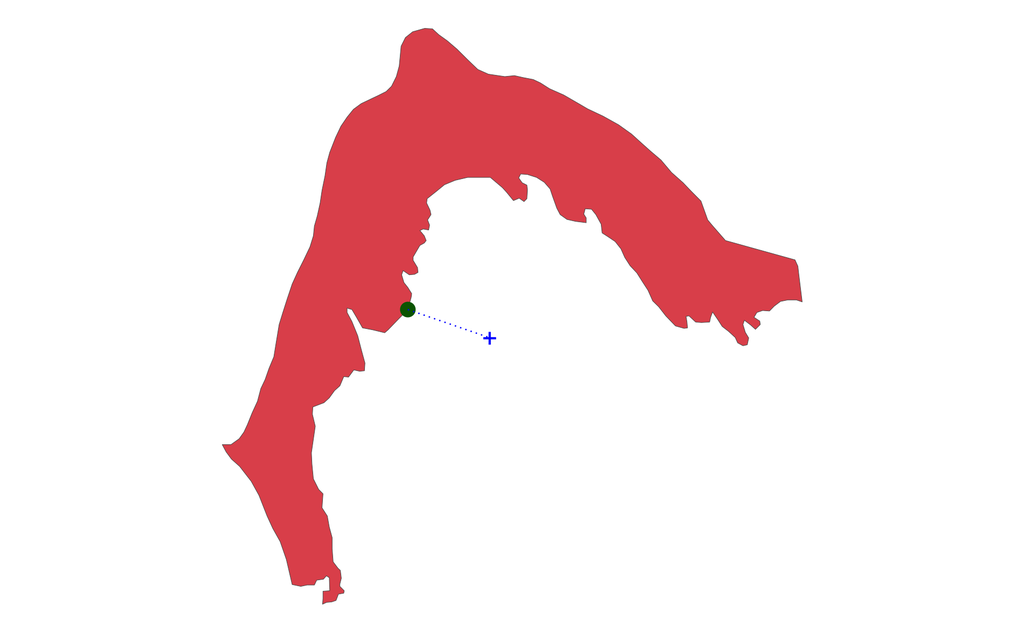

```r
pt <- getNearestPointOnGeometry(site.tr, mbc.tr.centroid, crs) %>%
  mutate(idx = max(as.numeric(candidate.pts$idx)) + 1)

p <- ggplot() +
  geom_sf(data=site.tr, fill=site.colour) +
  geom_sf(data=pt, shape = 19, colour = nearest.colour, size = 5) +
  geom_sf(data=mbc.tr.centroid, shape = '+', colour = centroid2.colour, size = 7) +
  geom_segment(aes(x = st_coordinates(pt)[1],
                   y = st_coordinates(pt)[2],
                   xend = st_coordinates(mbc.tr.centroid)[1],
                   yend = st_coordinates(mbc.tr.centroid)[2]),
               colour = centroid2.colour,
               linetype = "dotted") +
  theme_void() + theme(legend.position = "None")
p
```

#### 5.1.3 - Candidate points = geometry vertices sample + nearest point

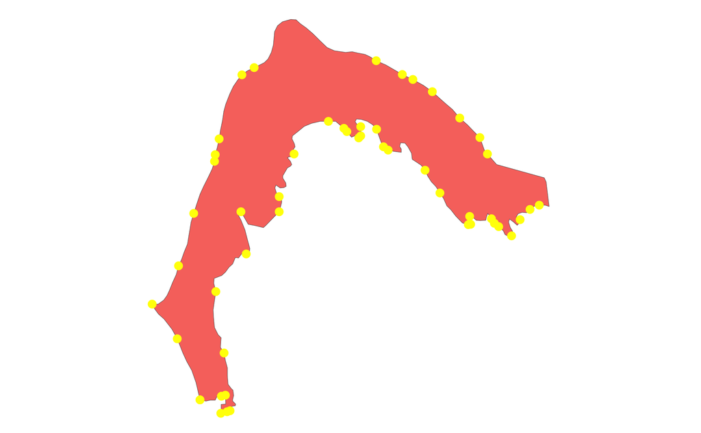

```r
if(need.cc){
  candidate.pts <- rbind(candidate.pts, pt)
    p <- ggplot() +
      geom_sf(data=site.tr, aes(fill=site.colour)) +
      geom_sf(data=candidate.pts, shape = 19, colour = candidate1.colour, size = 4) +
      theme_void() + theme(legend.position = "None")
    p
}
```

### 5.2 - Calculation of corrected center

To calculate the corrected center, **GeoPick** proceeds in two steps.

In a *first approximation* step it finds out which is the best candidate for the corrected center (5.2.1 green cross), i.e. which one minimizes uncertainty, among the candidate points (5.2.1 yellow dots).

Then, in a *second approximation* step, it explores whether it still can find out a better candidate among the nearest vertices (5.2.2 purple dots) to the point selected in the *first approximation* (5.2.1 green cross). These nearest vertices (5.2.2 purple dots) that are potential new candidates are drawn from the geometry vertices, which might not have been selected as candidates by the sampling process (5.1.1 black dots). *GeoPick* considers that within the *zone* where the *first approximation* found a candidate corrected center there might be a neighbour geometry vertex which can still improve the uncertainty.

In this example, the resulting corrected center (5.2.3 and 5.3 green cross) corresponds to the one found in the *first approximation* since the *second approximation* did not improve the uncertainty.

#### 5.2.1 - First approximation step

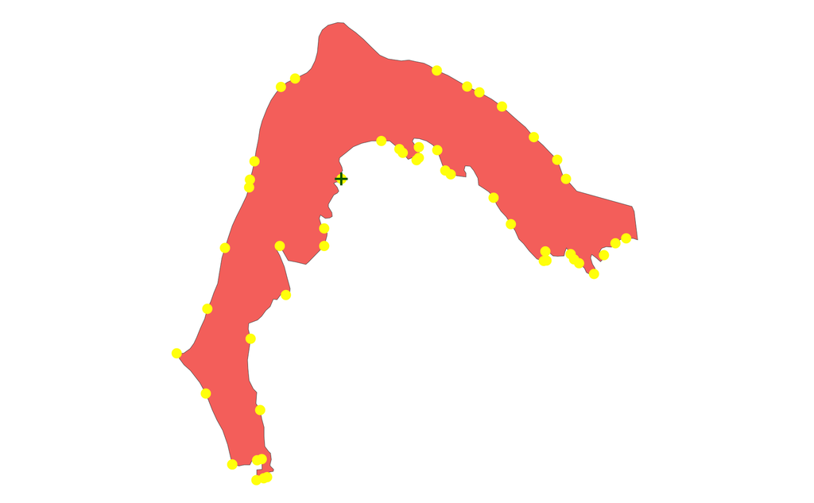

```r
if(need.cc){
  sec <- approximateSEC(site.pts, candidate.pts, NA, 10^8)
  p <- ggplot() +
    geom_sf(data=site.tr, aes(fill=site.colour)) +
    geom_sf(data=candidate.pts, shape = 19, colour = candidate1.colour, size = 4) +
    geom_sf(data=sec$center, shape = '+', colour = centroid1.colour, size = 9) +
    theme_void() + theme(legend.position = "none")
  p
}
```

#### 5.2.2 - Second approximation

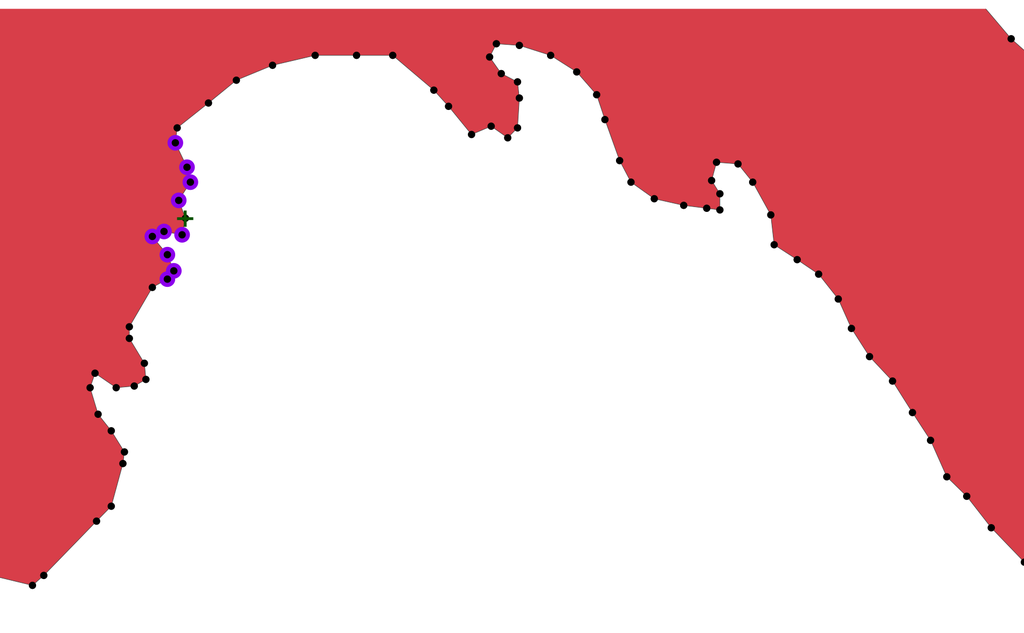

```r
if(need.cc){
  n.nearest <- 10
  # Once we have a first approximation through randomization, we explore the neighbours of the selected
  # point in order to to see if one of them still improves the sec
  nearest.pts <- getNearestPoints(site.pts, sec$center, n.nearest)
  sec.final <- approximateSEC(site.pts, nearest.pts, sec$center, sec$radius)
  radius.final <- sec$radius
  mbc.tr.corrected.centroid <- sec.final$center %>% dplyr::select(-idx)
  v <- terra::buffer(vect(mbc.tr.corrected.centroid), radius.final)
  mbc.tr.corrected <- st_as_sf(v)

  p <- ggplot() +
    geom_sf(data=site.tr, fill=site.colour) +
    geom_sf(data=nearest.pts, shape = 19, colour = candidate2.colour, size = 5) +
    geom_sf(data=site.pts, colour = vertex.colour, shape = 19, size = 2) +
    geom_sf(data=sec$center, shape = '+', colour = centroid1.colour, size = 9) +
    xlim(c(-70, 180)) +
    ylim(c(-80, 70)) +
    theme_void() + theme(legend.position = "none")
  p
}
```

#### 5.2.3 - Final selection of best corrected center.

```r
if(need.cc){
  xc.tr <- st_coordinates(sec.final$center)[1]
  yc.tr <- st_coordinates(sec.final$center)[2]
  radius.line <- st_as_sfc(paste0("LINESTRING (", xc.tr, " ", yc.tr, ", ",
                                  st_bbox(mbc.tr.corrected)["xmax"], " ", yc.tr, ")")) %>%
    st_set_crs(crs)
  uncertainty2 <- paste(round(st_length(radius.line)), "m")
}
```

### 5.3 - Final corrected center and associated uncertainty (in AEQD projection).

The distance from the corrected center to the furthest vertex in the geometry defines the smallest enclosing circle and, thus, the uncertainty. Note that the uncertainty (361 m m) of the corrected center is greater than the uncertainty (290 m m) of the non-corrected center in step 4 - Calculate SEC and centroid.

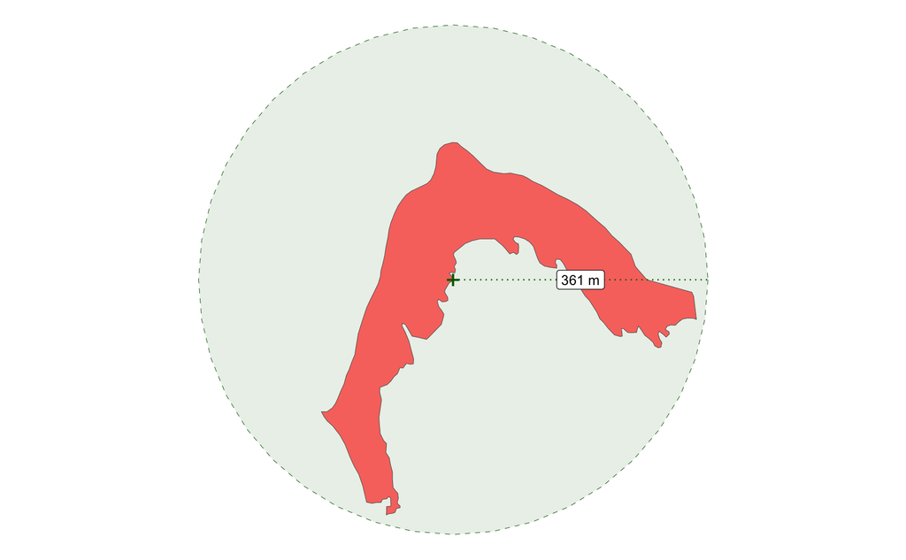

```r
if(need.cc){
p <- ggplot() +
  geom_sf(data=mbc.tr.corrected, colour = centroid1.colour,
          fill = centroid1.colour, alpha = 0.1, linetype = "dashed") +
  geom_sf(data=site.tr, aes(fill=site.colour)) +
  geom_sf(data=sec.final$center, shape = "+", colour = centroid1.colour, size = 7) +
  geom_sf(data=radius.line, linewidth = 0.5, linetype = "dotted", colour = centroid1.colour) +
  geom_label(aes(x = xc.tr + (st_bbox(mbc.tr.corrected)["xmax"] - xc.tr)/2, y = yc.tr),
             label = uncertainty2) +
  theme_void() +
  theme(legend.position = "none")
p
}
```

## 6 - Reprojection back to WGS84

Once **GeoPick** has determined which is the best candidate for the corrected center, it reprojects the results back to WGS84 and offers them to the user.

```r
if(need.cc){
  mbc.4326 <- st_transform(mbc.tr.corrected, 4326)
  centroid <- st_as_sf(mbc.tr.corrected.centroid) %>% st_transform(4326)
} else {
  mbc.4326 <- st_transform(mbc.tr, 4326)
  centroid <- st_as_sf(mbc.tr.centroid) %>% st_transform(4326)
}

leaflet() %>%
  addTiles() %>%
  addPolygons(data=mbc.4326, opacity = 0.25) %>%
  addPolygons(data=site.sf, col = site.colour) %>%
  addMarkers(data=centroid)
```

## References

[1] Wieczorek J, Guo Q, Hijmans R. (2004) The point-radius method for georeferencing locality descriptions and calculating associated uncertainty. International Journal of Geographical Information Science. 18:745–767. https://doi.org/10.1080/13658810412331280211. [2] Chapman AD & Wieczorek JR (2020) Georeferencing Best Practices. Copenhagen: GBIF Secretariat. [https://doi.org/10.35035/e09p-h128](https://doi.org/10.15468/doc-gg7h-s853)  
[3] Zermoglio PF, Chapman AD, Wieczorek JR, Luna MC & Bloom DA (2020) Georeferencing Quick Reference Guide. Copenhagen: GBIF Secretariat. https://doi.org/10.35035/e09p-h128  
[4] Pebesma, E. (2022). lwgeom: Bindings to Selected ‘liblwgeom’ Functions for Simple Features. R package version 0.2-10. https://CRAN.R-project.org/package=lwgeom